# Evaluación 02 - Juegos Olímpicos

Alumno: Daniel García Loyola  
Profesor: Israel Naranjo Retamal  
Ramo: Minería de datos (MDY7101)  
Sección: 002D  
Entrega: 12/06/2020  
Pregunta: 01

```python
import pandas as pd
import numpy as np
import matplotlib.pyplot as plt
import seaborn as sns
import warnings
```

```python
# Ajustes al notebook
warnings.filterwarnings('ignore')
plt.rcParams['figure.figsize'] = (8, 8)
```

# Cargando datos de juegos olímpicos

```python
data_file = "../data/original/JuegosOlimpicos.csv"
data = pd.read_csv(data_file, engine='python')
data.shape
```

```
(271116, 15)
```

Ajustando nombres de columnas.

```python
data.columns = [
    'ID', 'NombreAtleta', 'Sexo',
    'Edad', 'Altura', 'Peso',
    'Equipo', 'Comite',
    'JuegosOlimpicos', 'Año', 'Temporada', 'Ciudad',
    'Deporte', 'Competencia', 'Medalla']
data.columns
```

```
Index(['ID', 'NombreAtleta', 'Sexo', 'Edad', 'Altura', 'Peso', 'Equipo',
       'Comite', 'JuegosOlimpicos', 'Año', 'Temporada', 'Ciudad', 'Deporte',
       'Competencia', 'Medalla'],
      dtype='object')
```

# Explorando datos

```python
data.head()
```

|  | ID | NombreAtleta | Sexo | Edad | Altura | Peso | Equipo | Comite | JuegosOlimpicos | Año | Temporada | Ciudad | Deporte | Competencia | Medalla |
| --- | --- | --- | --- | --- | --- | --- | --- | --- | --- | --- | --- | --- | --- | --- | --- |
| 0 | 1 | A Dijiang | M | 24.0 | 180.0 | 80.0 | China | CHN | 1992 Summer | 1992 | Summer | Barcelona | Basketball | Basketball Men's Basketball | NaN |
| 1 | 2 | A Lamusi | M | 23.0 | 170.0 | 60.0 | China | CHN | 2012 Summer | 2012 | Summer | London | Judo | Judo Men's Extra-Lightweight | NaN |
| 2 | 3 | Gunnar Nielsen Aaby | M | 24.0 | NaN | NaN | Denmark | DEN | 1920 Summer | 1920 | Summer | Antwerpen | Football | Football Men's Football | NaN |
| 3 | 4 | Edgar Lindenau Aabye | M | 34.0 | NaN | NaN | Denmark/Sweden | DEN | 1900 Summer | 1900 | Summer | Paris | Tug-Of-War | Tug-Of-War Men's Tug-Of-War | Gold |
| 4 | 5 | Christine Jacoba Aaftink | F | 21.0 | 185.0 | 82.0 | Netherlands | NED | 1988 Winter | 1988 | Winter | Calgary | Speed Skating | Speed Skating Women's 500 metres | NaN |

```python
data.describe(include='all')
```

|  | ID | NombreAtleta | Sexo | Edad | Altura | Peso | Equipo | Comite | JuegosOlimpicos | Año | Temporada | Ciudad | Deporte | Competencia | Medalla |
| --- | --- | --- | --- | --- | --- | --- | --- | --- | --- | --- | --- | --- | --- | --- | --- |
| count | 271116.000000 | 271116 | 271116 | 261642.000000 | 210945.000000 | 208241.000000 | 271116 | 271116 | 271116 | 271116.000000 | 271116 | 271116 | 271116 | 271116 | 39783 |
| unique | NaN | 134732 | 2 | NaN | NaN | NaN | 1184 | 230 | 51 | NaN | 2 | 42 | 66 | 765 | 3 |
| top | NaN | Robert Tait McKenzie | M | NaN | NaN | NaN | United States | USA | 2000 Summer | NaN | Summer | London | Athletics | Football Men's Football | Gold |
| freq | NaN | 58 | 196594 | NaN | NaN | NaN | 17847 | 18853 | 13821 | NaN | 222552 | 22426 | 38624 | 5733 | 13372 |
| mean | 68248.954396 | NaN | NaN | 25.556898 | 175.338970 | 70.702393 | NaN | NaN | NaN | 1978.378480 | NaN | NaN | NaN | NaN | NaN |
| std | 39022.286345 | NaN | NaN | 6.393561 | 10.518462 | 14.348020 | NaN | NaN | NaN | 29.877632 | NaN | NaN | NaN | NaN | NaN |
| min | 1.000000 | NaN | NaN | 10.000000 | 127.000000 | 25.000000 | NaN | NaN | NaN | 1896.000000 | NaN | NaN | NaN | NaN | NaN |
| 25% | 34643.000000 | NaN | NaN | 21.000000 | 168.000000 | 60.000000 | NaN | NaN | NaN | 1960.000000 | NaN | NaN | NaN | NaN | NaN |
| 50% | 68205.000000 | NaN | NaN | 24.000000 | 175.000000 | 70.000000 | NaN | NaN | NaN | 1988.000000 | NaN | NaN | NaN | NaN | NaN |
| 75% | 102097.250000 | NaN | NaN | 28.000000 | 183.000000 | 79.000000 | NaN | NaN | NaN | 2002.000000 | NaN | NaN | NaN | NaN | NaN |
| max | 135571.000000 | NaN | NaN | 97.000000 | 226.000000 | 214.000000 | NaN | NaN | NaN | 2016.000000 | NaN | NaN | NaN | NaN | NaN |

```python
data.info()
```

```
<class 'pandas.core.frame.DataFrame'>
RangeIndex: 271116 entries, 0 to 271115
Data columns (total 15 columns):
 #   Column           Non-Null Count   Dtype
---  ------           --------------   -----
 0   ID               271116 non-null  int64
 1   NombreAtleta     271116 non-null  object
 2   Sexo             271116 non-null  object
 3   Edad             261642 non-null  float64
 4   Altura           210945 non-null  float64
 5   Peso             208241 non-null  float64
 6   Equipo           271116 non-null  object
 7   Comite           271116 non-null  object
 8   JuegosOlimpicos  271116 non-null  object
 9   Año              271116 non-null  int64
 10  Temporada        271116 non-null  object
 11  Ciudad           271116 non-null  object
 12  Deporte          271116 non-null  object
 13  Competencia      271116 non-null  object
 14  Medalla          39783 non-null   object
dtypes: float64(3), int64(2), object(10)
memory usage: 31.0+ MB
```

```python
data.dtypes
```

```
ID                   int64
NombreAtleta        object
Sexo                object
Edad               float64
Altura             float64
Peso               float64
Equipo              object
Comite              object
JuegosOlimpicos     object
Año                  int64
Temporada           object
Ciudad              object
Deporte             object
Competencia         object
Medalla             object
dtype: object
```

# Analisis y procesado de datos.

Se realizarán ajustes al dataframe para que el comportamiento frente a los modelos predictivos sea óptimo.

## Procesando elementos nulos

Para el estudio son requeridos las observaciones que poseen medallas, por lo tanto, tan solo estas observaciones serán tomadas en cuenta los atletas que no hayan ganado medallas serán eliminados del dataframe.

```python
print("Cantidad de elementos nulos por columna:")
data.isnull().sum()
```

```
Cantidad de elementos nulos por columna:
```

```
ID                      0
NombreAtleta            0
Sexo                    0
Edad                 9474
Altura              60171
Peso                62875
Equipo                  0
Comite                  0
JuegosOlimpicos         0
Año                     0
Temporada               0
Ciudad                  0
Deporte                 0
Competencia             0
Medalla            231333
dtype: int64
```

```python
data.dropna(inplace=True)
print("Resultado luego de eliminar nulos: ")
data.isnull().sum()
```

```
Resultado luego de eliminar nulos:
```

```
ID                 0
NombreAtleta       0
Sexo               0
Edad               0
Altura             0
Peso               0
Equipo             0
Comite             0
JuegosOlimpicos    0
Año                0
Temporada          0
Ciudad             0
Deporte            0
Competencia        0
Medalla            0
dtype: int64
```

## Transformando variables

Cambiar ciertas columnas para un mejor tratamiento de los datos relacionados.

```python
print("Cambiando columna sexo a valores numéricos")
data['Sexo_temp'] = 0
data.loc[data.Sexo == 'M', 'Sexo_temp'] = 1
data.loc[data.Sexo == 'F', 'Sexo_temp'] = 0
```

```
Cambiando columna sexo a valores numéricos
```

```python
print("Cambiando columna medalla a valores numéricos")
data['Medalla_temp'] = 0
data.loc[data.Medalla == 'Gold', 'Medalla_temp'] = 1
data.loc[data.Medalla == 'Silver', 'Medalla_temp'] = 2
data.loc[data.Medalla == 'Bronze', 'Medalla_temp'] = 3
```

```
Cambiando columna medalla a valores numéricos
```

```python
data.head(15)
```

|  | ID | NombreAtleta | Sexo | Edad | Altura | Peso | Equipo | Comite | JuegosOlimpicos | Año | Temporada | Ciudad | Deporte | Competencia | Medalla | Sexo_temp | Medalla_temp |
| --- | --- | --- | --- | --- | --- | --- | --- | --- | --- | --- | --- | --- | --- | --- | --- | --- | --- |
| 40 | 16 | Juhamatti Tapio Aaltonen | M | 28.0 | 184.0 | 85.0 | Finland | FIN | 2014 Winter | 2014 | Winter | Sochi | Ice Hockey | Ice Hockey Men's Ice Hockey | Bronze | 1 | 3 |
| 41 | 17 | Paavo Johannes Aaltonen | M | 28.0 | 175.0 | 64.0 | Finland | FIN | 1948 Summer | 1948 | Summer | London | Gymnastics | Gymnastics Men's Individual All-Around | Bronze | 1 | 3 |
| 42 | 17 | Paavo Johannes Aaltonen | M | 28.0 | 175.0 | 64.0 | Finland | FIN | 1948 Summer | 1948 | Summer | London | Gymnastics | Gymnastics Men's Team All-Around | Gold | 1 | 1 |
| 44 | 17 | Paavo Johannes Aaltonen | M | 28.0 | 175.0 | 64.0 | Finland | FIN | 1948 Summer | 1948 | Summer | London | Gymnastics | Gymnastics Men's Horse Vault | Gold | 1 | 1 |
| 48 | 17 | Paavo Johannes Aaltonen | M | 28.0 | 175.0 | 64.0 | Finland | FIN | 1948 Summer | 1948 | Summer | London | Gymnastics | Gymnastics Men's Pommelled Horse | Gold | 1 | 1 |
| 50 | 17 | Paavo Johannes Aaltonen | M | 32.0 | 175.0 | 64.0 | Finland | FIN | 1952 Summer | 1952 | Summer | Helsinki | Gymnastics | Gymnastics Men's Team All-Around | Bronze | 1 | 3 |
| 60 | 20 | Kjetil Andr Aamodt | M | 20.0 | 176.0 | 85.0 | Norway | NOR | 1992 Winter | 1992 | Winter | Albertville | Alpine Skiing | Alpine Skiing Men's Super G | Gold | 1 | 1 |
| 61 | 20 | Kjetil Andr Aamodt | M | 20.0 | 176.0 | 85.0 | Norway | NOR | 1992 Winter | 1992 | Winter | Albertville | Alpine Skiing | Alpine Skiing Men's Giant Slalom | Bronze | 1 | 3 |
| 63 | 20 | Kjetil Andr Aamodt | M | 22.0 | 176.0 | 85.0 | Norway | NOR | 1994 Winter | 1994 | Winter | Lillehammer | Alpine Skiing | Alpine Skiing Men's Downhill | Silver | 1 | 2 |
| 64 | 20 | Kjetil Andr Aamodt | M | 22.0 | 176.0 | 85.0 | Norway | NOR | 1994 Winter | 1994 | Winter | Lillehammer | Alpine Skiing | Alpine Skiing Men's Super G | Bronze | 1 | 3 |
| 67 | 20 | Kjetil Andr Aamodt | M | 22.0 | 176.0 | 85.0 | Norway | NOR | 1994 Winter | 1994 | Winter | Lillehammer | Alpine Skiing | Alpine Skiing Men's Combined | Silver | 1 | 2 |
| 73 | 20 | Kjetil Andr Aamodt | M | 30.0 | 176.0 | 85.0 | Norway | NOR | 2002 Winter | 2002 | Winter | Salt Lake City | Alpine Skiing | Alpine Skiing Men's Super G | Gold | 1 | 1 |
| 76 | 20 | Kjetil Andr Aamodt | M | 30.0 | 176.0 | 85.0 | Norway | NOR | 2002 Winter | 2002 | Winter | Salt Lake City | Alpine Skiing | Alpine Skiing Men's Combined | Gold | 1 | 1 |
| 78 | 20 | Kjetil Andr Aamodt | M | 34.0 | 176.0 | 85.0 | Norway | NOR | 2006 Winter | 2006 | Winter | Torino | Alpine Skiing | Alpine Skiing Men's Super G | Gold | 1 | 1 |
| 92 | 30 | Pepijn Aardewijn | M | 26.0 | 189.0 | 72.0 | Netherlands | NED | 1996 Summer | 1996 | Summer | Atlanta | Rowing | Rowing Men's Lightweight Double Sculls | Silver | 1 | 2 |

## Eliminar columnas inecesarias en el dataframe

```python
columnas = [
    'ID', 'NombreAtleta', 'Sexo',
    'JuegosOlimpicos', 'Temporada', 'Ciudad',
    'Año', 'Equipo', 'Comite', 'Competencia']
data = data.drop(columnas, axis=1)
data.head()
```

|  | Edad | Altura | Peso | Deporte | Medalla | Sexo_temp | Medalla_temp |
| --- | --- | --- | --- | --- | --- | --- | --- |
| 40 | 28.0 | 184.0 | 85.0 | Ice Hockey | Bronze | 1 | 3 |
| 41 | 28.0 | 175.0 | 64.0 | Gymnastics | Bronze | 1 | 3 |
| 42 | 28.0 | 175.0 | 64.0 | Gymnastics | Gold | 1 | 1 |
| 44 | 28.0 | 175.0 | 64.0 | Gymnastics | Gold | 1 | 1 |
| 48 | 28.0 | 175.0 | 64.0 | Gymnastics | Gold | 1 | 1 |

```python
print("Restableciendo nombres de columnas")
data.columns = [
    'Edad', 'Altura', 'Peso',
    'Deporte', 'Medalla', 'Sexo', 'MedallaNum']
data.columns
```

```
Restableciendo nombres de columnas
```

```
Index(['Edad', 'Altura', 'Peso', 'Deporte', 'Medalla', 'Sexo', 'MedallaNum'], dtype='object')
```

# Visualizando correlación de las columnas

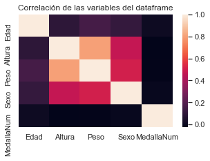

```python
data_corr = data.corr(method='pearson')
sns.set_style(style='white')
fig, ax = plt.subplots(figsize=(5, 3))
sns.heatmap(data_corr, ax=ax)
plt.title("Correlación de las variables del dataframe")
```

```python
data_corr
```

|  | Edad | Altura | Peso | Sexo | MedallaNum |
| --- | --- | --- | --- | --- | --- |
| Edad | 1.000000 | 0.095942 | 0.161750 | 0.118950 | 0.013261 |
| Altura | 0.095942 | 1.000000 | 0.801831 | 0.470164 | -0.024170 |
| Peso | 0.161750 | 0.801831 | 1.000000 | 0.507178 | -0.017563 |
| Sexo | 0.118950 | 0.470164 | 0.507178 | 1.000000 | -0.003787 |
| MedallaNum | 0.013261 | -0.024170 | -0.017563 | -0.003787 | 1.000000 |

Se puede ver que existe una alta correlación entre altura y peso, la columna sexo, posee una debil correlacion con las mencionadas anteriormente, las demás columnas no poseen relación alguna entre si.

# Verificando distribución de las columnas

Se requere verificar la distribución para poder saber si es que debe ser aplicado algún metodo de standarización a los datos, las variables interesantes para este estudio corresponden a la edad, altura ypeso de los atletas, por lo tanto, las correcciones serán realizadas a dichas columnas, las demás pueden que sirvan de predictores solamente.

```python
from scipy import stats
```

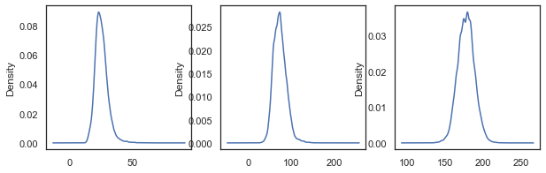

```python
plt.figure(figsize=(10, 3))
plt.title('Relación de simetria de las columnas edad, peso y altura')
plt.subplot(1, 3, 1)
data.Edad.plot.kde()
plt.subplot(1, 3, 2)
data.Peso.plot.kde()
plt.subplot(1, 3, 3)
data.Altura.plot.kde()
plt.show()
```

```python
print('Coeficientes de simetría: ')
print('Edad    : ', stats.skew(data.Edad), sep='\t')
print('Peso    : ', stats.skew(data.Peso), sep='\t')
print('Altura : ', stats.skew(data.Altura), sep='\t')
```

```
Coeficientes de simetría:
Edad    : 	1.067400585357262
Peso    : 	0.6894054869942579
Altura : 	0.041995987904002885
```

Vemos que las columnas estan mas cargadas al costado derecho del gráfico, será necesario realizar la eliminación de extremos para poder normalizar las columnas y asi los modelos predictivos a aplicar no se sesgaran por los valores mas altos que encuentren.

```python
def quitar_extremos(df):
    cantidad_outliers = 0
    for columna in df:
        if df[columna].dtype != np.object:
            n_outliers = len(df[np.abs(stats.zscore(df[columna])) > 3])
            print("{} {} {}".format(
                df[columna].name, n_outliers, df[columna].dtype))
            if n_outliers > 0:
                cantidad_outliers = n_outliers
    return True if cantidad_outliers > 0 else False
```

```python
while quitar_extremos(data[['Edad', 'Peso', 'Altura']]):
    data = data[
        (np.abs(stats.zscore(data.Edad)) < 3)  &
        (np.abs(stats.zscore(data.Peso)) < 3) &
        (np.abs(stats.zscore(data.Altura)) < 3)]
```

```
Edad 352 float64
Peso 286 float64
Altura 116 float64
Edad 184 float64
Peso 87 float64
Altura 42 float64
Edad 0 float64
Peso 0 float64
Altura 0 float64
```

Ahora vuelvo a visualizar para verificar que los extremos fueron eliminados correctamente.

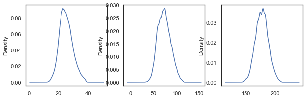

```python
plt.figure(figsize=(10, 3))
plt.title('Relación de simetria de las columnas edad, peso y altura')
plt.subplot(1, 3, 1)
data.Edad.plot.kde()
plt.subplot(1, 3, 2)
data.Peso.plot.kde()
plt.subplot(1, 3, 3)
data.Altura.plot.kde()
plt.show()
```

```python
print('Coeficientes de simetría: ')
print('Edad    : ', stats.skew(data.Edad), sep='\t')
print('Peso    : ', stats.skew(data.Peso), sep='\t')
print('Altura : ', stats.skew(data.Altura), sep='\t')
```

```
Coeficientes de simetría:
Edad    : 	0.3507844651697528
Peso    : 	0.23401765103866498
Altura : 	0.024301969888423976
```

Ahora las columnas de edad, peso y altura estan normalizadas, esto permitirá que los modelos sean mas parejos para realizar las preddicciones, recordar que deben ser eliminados los extremos (outliers) antes de proseguir con el ejercicio.

# Visualizando los tipos de medallas

Debemos conocer el estado de la dictribución de los tipos de medallas para saber que tal será el desempeño del atleta a mostrar.

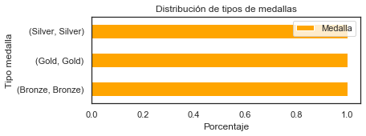

```python
plt.figure(figsize=(6, 2))
data.groupby('Medalla')['Medalla'].value_counts(normalize=True).plot(kind='barh', legend='best', color='orange')
plt.title('Distribución de tipos de medallas')
plt.xlabel('Porcentaje')
plt.ylabel('Tipo medalla')
plt.show()
```

```python
print('Tipos de medallas')
data.Medalla.value_counts()
```

```
Tipos de medallas
```

```
Gold      9823
Bronze    9789
Silver    9525
Name: Medalla, dtype: int64
```

```python
# ## Medallas de oro
```

```python
df_oro = data.loc[data["Medalla"] == 'Gold', ]
while quitar_extremos(df_oro[['Edad', 'Peso', 'Altura']]):
    df_oro = df_oro[
        (np.abs(stats.zscore(df_oro.Edad)) < 3)  &
        (np.abs(stats.zscore(df_oro.Peso)) < 3) &
        (np.abs(stats.zscore(df_oro.Altura)) < 3)
        ]
```

```
Edad 0 float64
Peso 0 float64
Altura 0 float64
```

```python
def generar_grafico(df, columna, color):
    grafico = sns.distplot(
        df[columna],
        rug=True, rug_kws={"color": color},
        kde_kws={"color": "k", "lw": 3, "label": columna},
        hist_kws={"histtype": "step", "linewidth": 3, "alpha": 1, "color": color})
    return grafico
```

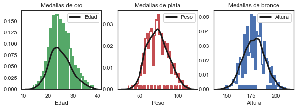

```python
plt.figure(figsize=(10, 3))
plt.subplot(1, 3, 1)
plt.title('Medallas de oro')
generar_grafico(df_oro, 'Edad', 'g')
plt.subplot(1, 3, 2)
generar_grafico(df_oro, 'Peso', 'r')
plt.title('Medallas de plata')
plt.subplot(1, 3, 3)
generar_grafico(df_oro, 'Altura', 'b')
plt.title('Medallas de bronce')
plt.show()
```

```python
# ## Medallas de plata
```

```python
df_plata = data.loc[data["Medalla"] == 'Silver', ]
while quitar_extremos(df_plata[['Edad', 'Peso', 'Altura']]):
    df_plata = df_plata[
        (np.abs(stats.zscore(df_plata.Edad)) < 3)  &
        (np.abs(stats.zscore(df_plata.Peso)) < 3) &
        (np.abs(stats.zscore(df_plata.Altura)) < 3)
        ]
```

```
Edad 0 float64
Peso 6 float64
Altura 0 float64
Edad 0 float64
Peso 0 float64
Altura 4 float64
Edad 0 float64
Peso 0 float64
Altura 0 float64
```

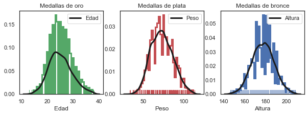

```python
plt.figure(figsize=(10, 3))
plt.subplot(1, 3, 1)
plt.title('Medallas de oro')
generar_grafico(df_plata, 'Edad', 'g')
plt.subplot(1, 3, 2)
generar_grafico(df_plata, 'Peso', 'r')
plt.title('Medallas de plata')
plt.subplot(1, 3, 3)
generar_grafico(df_plata, 'Altura', 'b')
plt.title('Medallas de bronce')
plt.show()
```

```python
# ## Medallas de bronze
```

```python
df_bronce = data.loc[data["Medalla"] == 'Bronze', ]
while quitar_extremos(df_bronce[['Edad', 'Peso', 'Altura']]):
    df_bronce = df_bronce[
        (np.abs(stats.zscore(df_bronce.Edad)) < 3)  &
        (np.abs(stats.zscore(df_bronce.Peso)) < 3) &
        (np.abs(stats.zscore(df_bronce.Altura)) < 3)
        ]
```

```
Edad 0 float64
Peso 8 float64
Altura 0 float64
Edad 0 float64
Peso 0 float64
Altura 0 float64
```

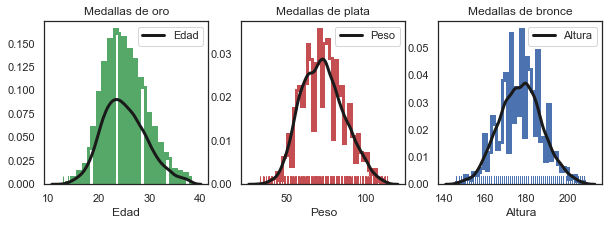

```python
plt.figure(figsize=(10, 3))
plt.subplot(1, 3, 1)
plt.title('Medallas de oro')
generar_grafico(df_bronce, 'Edad', 'g')
plt.subplot(1, 3, 2)
generar_grafico(df_bronce, 'Peso', 'r')
plt.title('Medallas de plata')
plt.subplot(1, 3, 3)
generar_grafico(df_bronce, 'Altura', 'b')
plt.title('Medallas de bronce')
plt.show()
```

Luego de visualizar, procesar y explorar los datos, estamos en condiciones de poder aplicar los modelos necesarios para el ejercicio.

# Calcular las probabilidades que posee un atleta

Para el ejercicio, es necesario aplicar diferentes modelos que nos permitan ingresar la edad, peso, altura sexo y deporte para poder visualizar si el atleta tendrá posibilidades de exito en los próximos juegos olímpicos de Tokio 2020.

```python
def obtener_dataframe(df, sexo, deporte, medalla):
    deporte_atleta = data.loc[:, 'Deporte'].str.contains(deporte, case=False)
    sexo_atleta = data.loc[:, 'Sexo'] == sexo
    if not deporte:
        df = df.loc[sexo_atleta]
    elif not sexo:
        df = df.loc[deporte_atleta]
    elif not sexo and not deporte:
        df = df
    else:
        df = df.loc[deporte_atleta & sexo_atleta]
    if medalla:
        medalla_atleta = data.loc[:, 'Medalla'] == medalla
        df = df.loc[medalla_atleta]
    return df
```

Los datos a utilizar para este ejercicio son los de la atleta **Kristel Koubrick**

```python
edad = 34
peso = 61
altura = 161
sexo = 0
deporte = 'Swimming'
data_new = obtener_dataframe(data, sexo, deporte, '').drop_duplicates()
data_new = data_new.drop(['Medalla'], axis=1)
data_new = data_new.sort_values(['Edad', 'Altura', 'Peso'])
data_new
```

|  | Edad | Altura | Peso | Deporte | Sexo | MedallaNum |
| --- | --- | --- | --- | --- | --- | --- |
| 44972 | 13.0 | 157.0 | 45.0 | Swimming | 0 | 3 |
| 52010 | 13.0 | 168.0 | 61.0 | Swimming | 0 | 1 |
| 170652 | 13.0 | 168.0 | 61.0 | Swimming | 0 | 2 |
| 63524 | 13.0 | 172.0 | 59.0 | Swimming | 0 | 2 |
| 104649 | 14.0 | 159.0 | 50.0 | Swimming | 0 | 1 |
| ... | ... | ... | ... | ... | ... | ... |
| 237085 | 35.0 | 165.0 | 66.0 | Swimming | 1 | 3 |
| 64650 | 35.0 | 191.0 | 80.0 | Swimming | 1 | 1 |
| 78988 | 36.0 | 185.0 | 78.0 | Swimming | 1 | 2 |
| 137867 | 36.0 | 193.0 | 98.0 | Swimming | 1 | 2 |
| 202031 | 37.0 | 183.0 | 76.0 | Swimming | 1 | 2 |

2098 rows × 6 columns

```python
from sklearn.linear_model import LinearRegression
from sklearn.feature_selection import RFE
from sklearn.svm import SVR
from sklearn.model_selection import train_test_split
from sklearn.metrics import mean_squared_error
resultados = []
resultados_oro = []
resultados_plata = []
resultados_bronce = []
```

Revisar si las columnas son aptas para el modelo

```python
def validar_columnas(df, tipo, X_columnas, y_columnas):
    X = df[X_columnas]
    Y = df[y_columnas]
    estimador = SVR(kernel=tipo)
    seleccionador = RFE(estimador, len(X), step=1)
    seleccionador = seleccionador.fit(X, Y)
    print(seleccionador.support_)
    return
```

Generar los conjuntos de entrenamiento y test

```python
def generar_entrenamiento(df, X_columnas, y_columnas):
    X = np.array(df[X_columnas])
    y = np.array(df[[y_columnas]].values)
    X_train, X_test, y_train, y_test = train_test_split(X, y, test_size=0.2)
    return X_train, X_test, y_train, y_test
```

## Regresión lineal

### Probabilidad general de obtener medallas

```python
def mostrar_variables(interseccion, coeficiente, score, error_cuadratico):
    print()
    print('Intersección     :', interseccion, sep='\t')
    print('Coeficiente      :', coeficiente, sep='\t')
    print('Score            :', score, sep='\t')
    print('"Error cuadrático :', error_cuadratico, sep='\t')
    return
```

```python
X_columnas = ['Edad', 'Peso', 'Altura']
y_columnas = 'MedallaNum'
validar_columnas(data_new, 'linear', X_columnas, y_columnas)
X_train, X_test, y_train, y_test = generar_entrenamiento(data_new, X_columnas, y_columnas)
lm = LinearRegression()
lm.fit(X_train, y_train)
y_pred = lm.predict(X_train)
interseccion = lm.intercept_[0]
coeficiente = lm.coef_[0][0]
score = lm.score(X_train, y_train)
error_cuadratico = mean_squared_error(y_train, y_pred)
mostrar_variables(interseccion, coeficiente, score, error_cuadratico)
```

```
[ True  True  True]

Intersección     :	3.059133493007441
Coeficiente      :	0.008413340027855013
Score            :	0.004327596749350682
"Error cuadrático :	0.6503704595549021
```

Aplicar la formula a los elementos del dataframe

```python
def aplicar_formula(df, coeficiente, interseccion):
    df['re'] = df[['Edad']].apply(lambda x: (coeficiente*x.Edad+interseccion), axis=1)
    df['rp'] = df[['Peso']].apply(lambda x: (coeficiente*x.Peso+interseccion), axis=1)
    df['ra'] = df[['Altura']].apply(lambda x: (coeficiente*x.Altura+interseccion), axis=1)
    return df
data_new = aplicar_formula(data_new, coeficiente, interseccion)
data_new.head(5)
```

|  | Edad | Altura | Peso | Deporte | Sexo | MedallaNum | re | rp | ra |
| --- | --- | --- | --- | --- | --- | --- | --- | --- | --- |
| 44972 | 13.0 | 157.0 | 45.0 | Swimming | 0 | 3 | 3.168507 | 3.437734 | 4.380028 |
| 52010 | 13.0 | 168.0 | 61.0 | Swimming | 0 | 1 | 3.168507 | 3.572347 | 4.472575 |
| 170652 | 13.0 | 168.0 | 61.0 | Swimming | 0 | 2 | 3.168507 | 3.572347 | 4.472575 |
| 63524 | 13.0 | 172.0 | 59.0 | Swimming | 0 | 2 | 3.168507 | 3.555521 | 4.506228 |
| 104649 | 14.0 | 159.0 | 50.0 | Swimming | 0 | 1 | 3.176920 | 3.479800 | 4.396855 |

#### Graficar resultados aplicados al dataframe

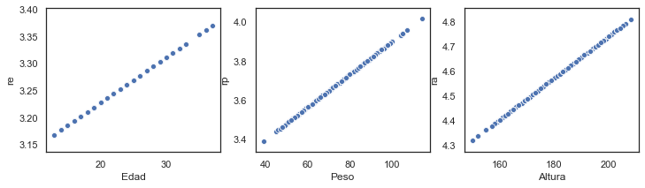

```python
def graficar_resultados(df):
    plt.figure(figsize=(12, 3))
    plt.subplot(1, 3, 1)
    sns.scatterplot(df.Edad, df.re)
    plt.subplot(1, 3, 2)
    sns.scatterplot(df.Peso, df.rp)
    plt.subplot(1, 3, 3)
    sns.scatterplot(df.Altura, df.ra)
    plt.show()
    return
graficar_resultados(data_new)
```

#### Predecir por las características del atleta

```python
y_pred = lm.predict(np.array([[edad, peso, altura]]))
prediccion = y_pred[0][0]
print('La probabilidad de ganar medalla es : {:.3f}'.format(prediccion))
resultados.append(['Regresión lineal', score, interseccion, coeficiente, error_cuadratico, prediccion])
```

```
La probabilidad de ganar medalla es : 2.275
```

### Probabilidad medalla de oro

Obtener datos para medalla de **oro**

```python
import random
data_oro = obtener_dataframe(data, sexo, deporte, 'Gold').drop_duplicates()
data_oro = data_oro.drop(['Sexo', 'Medalla', 'Deporte'], axis=1)
data_oro.MedallaNum = data_oro[['MedallaNum']].apply(lambda x : random.randrange(5), axis=1)
data_oro = data_oro.sort_values(['Edad', 'Altura', 'Peso'])
data_oro.head(5)
```

|  | Edad | Altura | Peso | MedallaNum |
| --- | --- | --- | --- | --- |
| 52010 | 13.0 | 168.0 | 61.0 | 4 |
| 104649 | 14.0 | 159.0 | 50.0 | 0 |
| 262733 | 14.0 | 167.0 | 60.0 | 3 |
| 163440 | 14.0 | 167.0 | 67.0 | 2 |
| 172293 | 14.0 | 172.0 | 62.0 | 4 |

Realizar las predicciones

```python
validar_columnas(data_oro, 'linear', X_columnas, y_columnas)
X_train, X_test, y_train, y_test = generar_entrenamiento(data_oro, X_columnas, y_columnas)
lm = LinearRegression()
lm.fit(X_train, y_train)
y_pred = lm.predict(X_train)
interseccion = lm.intercept_[0]
coeficiente = lm.coef_[0][0]
score = lm.score(X_train, y_train)
error_cuadratico = mean_squared_error(y_train, y_pred)
mostrar_variables(interseccion, coeficiente, score, error_cuadratico)
```

```
[ True  True  True]

Intersección     :	2.554603101215471
Coeficiente      :	0.008074415302049536
Score            :	0.0006455691754673198
"Error cuadrático :	2.0545751396680876
```

Aplicar la formula a los elementos del dataframe

```python
data_oro = aplicar_formula(data_oro, coeficiente, interseccion)
data_oro.head(5)
```

|  | Edad | Altura | Peso | MedallaNum | re | rp | ra |
| --- | --- | --- | --- | --- | --- | --- | --- |
| 52010 | 13.0 | 168.0 | 61.0 | 4 | 2.659571 | 3.047142 | 3.911105 |
| 104649 | 14.0 | 159.0 | 50.0 | 0 | 2.667645 | 2.958324 | 3.838435 |
| 262733 | 14.0 | 167.0 | 60.0 | 3 | 2.667645 | 3.039068 | 3.903030 |
| 163440 | 14.0 | 167.0 | 67.0 | 2 | 2.667645 | 3.095589 | 3.903030 |
| 172293 | 14.0 | 172.0 | 62.0 | 4 | 2.667645 | 3.055217 | 3.943403 |

#### Graficar resultados aplicados al dataframe

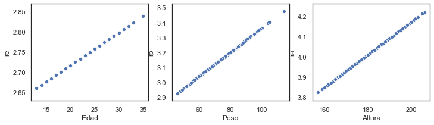

```python
graficar_resultados(data_oro)
```

#### Predecir por las características del atleta

```python
y_pred = lm.predict(np.array([[edad, peso, altura]]))
prediccion = y_pred[0][0]
print('La probabilidad de ganar medalla de oro es : {:.3f}'.format(prediccion))
resultados_oro.append(['Regresión lineal', score, interseccion, coeficiente, error_cuadratico, prediccion])
```

```
La probabilidad de ganar medalla de oro es : 2.212
```

### Probabilidad medalla de **plata**

Obtener datos para medalla de plata

```python
data_plata = obtener_dataframe(data, sexo, deporte, 'Silver').drop_duplicates()
data_plata = data_plata.drop(['Sexo', 'Medalla', 'Deporte'], axis=1)
data_plata.MedallaNum = data_plata[['MedallaNum']].apply(lambda x : random.randrange(4), axis=1)
data_plata = data_plata.sort_values(['Edad', 'Altura', 'Peso'])
data_plata.head(5)
```

|  | Edad | Altura | Peso | MedallaNum |
| --- | --- | --- | --- | --- |
| 170652 | 13.0 | 168.0 | 61.0 | 3 |
| 63524 | 13.0 | 172.0 | 59.0 | 0 |
| 122915 | 14.0 | 170.0 | 61.0 | 1 |
| 259436 | 14.0 | 171.0 | 60.0 | 0 |
| 16847 | 14.0 | 173.0 | 59.0 | 1 |

Realizar las predicciones

```python
validar_columnas(data_plata, 'linear', X_columnas, y_columnas)
X_train, X_test, y_train, y_test = generar_entrenamiento(data_plata, X_columnas, y_columnas)
lm = LinearRegression()
lm.fit(X_train, y_train)
y_pred = lm.predict(X_train)
interseccion = lm.intercept_[0]
coeficiente = lm.coef_[0][0]
score = lm.score(X_train, y_train)
error_cuadratico = mean_squared_error(y_train, y_pred)
mostrar_variables(interseccion, coeficiente, score, error_cuadratico)
```

```
[ True  True  True]

Intersección     :	1.778550093898278
Coeficiente      :	-0.014476290139007525
Score            :	0.0034011181285330543
"Error cuadrático :	1.1913851694946536
```

Aplicar la formula a los elementos del dataframe

```python
data_plata = aplicar_formula(data_plata, coeficiente, interseccion)
data_plata.head(5)
```

|  | Edad | Altura | Peso | MedallaNum | re | rp | ra |
| --- | --- | --- | --- | --- | --- | --- | --- |
| 170652 | 13.0 | 168.0 | 61.0 | 3 | 1.590358 | 0.895496 | -0.653467 |
| 63524 | 13.0 | 172.0 | 59.0 | 0 | 1.590358 | 0.924449 | -0.711372 |
| 122915 | 14.0 | 170.0 | 61.0 | 1 | 1.575882 | 0.895496 | -0.682419 |
| 259436 | 14.0 | 171.0 | 60.0 | 0 | 1.575882 | 0.909973 | -0.696896 |
| 16847 | 14.0 | 173.0 | 59.0 | 1 | 1.575882 | 0.924449 | -0.725848 |

#### Graficar resultados aplicados al dataframe

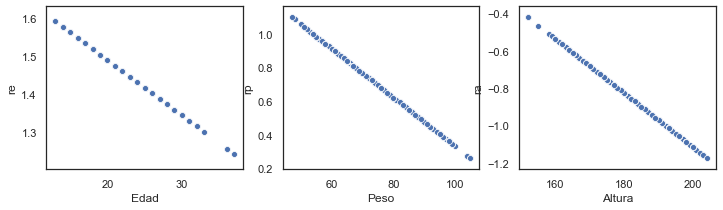

```python
graficar_resultados(data_plata)
```

#### Predecir por las características del atleta

```python
y_pred = lm.predict(np.array([[edad, peso, altura]]))
prediccion = y_pred[0][0]
print('La probabilidad de ganar medalla de plata es : {:.3f}'.format(prediccion))
resultados_plata.append(['Regresión lineal', score, interseccion, coeficiente, error_cuadratico, prediccion])
```

```
La probabilidad de ganar medalla de plata es : 1.345
```

### Probabilidad medalla de **bronce**

Obtener datos para medalla de bronce

```python
data_bronce = obtener_dataframe(data, sexo, deporte, 'Bronze').drop_duplicates()
data_bronce = data_bronce.drop(['Sexo', 'Medalla', 'Deporte'], axis=1)
data_bronce.MedallaNum = data_bronce[['MedallaNum']].apply(lambda x : random.randrange(3), axis=1)
data_bronce = data_bronce.sort_values(['Edad', 'Altura', 'Peso'])
data_bronce.head(5)
```

|  | Edad | Altura | Peso | MedallaNum |
| --- | --- | --- | --- | --- |
| 44972 | 13.0 | 157.0 | 45.0 | 0 |
| 162947 | 14.0 | 168.0 | 53.0 | 1 |
| 75741 | 14.0 | 168.0 | 54.0 | 1 |
| 196533 | 14.0 | 171.0 | 62.0 | 2 |
| 206627 | 14.0 | 173.0 | 63.0 | 1 |

Realizar las predicciones

```python
validar_columnas(data_bronce, 'linear', X_columnas, y_columnas)
X_train, X_test, y_train, y_test = generar_entrenamiento(data_bronce, X_columnas, y_columnas)
lm = LinearRegression()
lm.fit(X_train, y_train)
y_pred = lm.predict(X_train)
interseccion = lm.intercept_[0]
coeficiente = lm.coef_[0][0]
score = lm.score(X_train, y_train)
error_cuadratico = mean_squared_error(y_train, y_pred)
mostrar_variables(interseccion, coeficiente, score, error_cuadratico)
```

```
[ True  True  True]

Intersección     :	0.8012614465240359
Coeficiente      :	0.0012701478146028972
Score            :	0.0008215385723497892
"Error cuadrático :	0.6525409034724283
```

Aplicar la formula a los elementos del dataframe

```python
data_bronce = aplicar_formula(data_bronce, coeficiente, interseccion)
data_bronce.head(5)
```

|  | Edad | Altura | Peso | MedallaNum | re | rp | ra |
| --- | --- | --- | --- | --- | --- | --- | --- |
| 44972 | 13.0 | 157.0 | 45.0 | 0 | 0.817773 | 0.858418 | 1.000675 |
| 162947 | 14.0 | 168.0 | 53.0 | 1 | 0.819044 | 0.868579 | 1.014646 |
| 75741 | 14.0 | 168.0 | 54.0 | 1 | 0.819044 | 0.869849 | 1.014646 |
| 196533 | 14.0 | 171.0 | 62.0 | 2 | 0.819044 | 0.880011 | 1.018457 |
| 206627 | 14.0 | 173.0 | 63.0 | 1 | 0.819044 | 0.881281 | 1.020997 |

#### Graficar resultados aplicados al dataframe

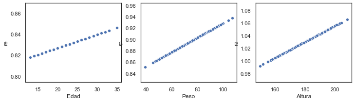

```python
graficar_resultados(data_bronce)
```

#### Predecir por las características del atleta

```python
y_pred = lm.predict(np.array([[edad, peso, altura]]))
prediccion = y_pred[0][0]
print('La probabilidad de ganar medalla de bronce es : {:.3f}'.format(prediccion))
resultados_bronce.append(['Regresión lineal', score, interseccion, coeficiente, error_cuadratico, prediccion])
```

```
La probabilidad de ganar medalla de bronce es : 1.045
```

## Regresión logistica

```python
from sklearn.linear_model import LogisticRegression
from sklearn.preprocessing import StandardScaler
from sklearn import metrics
```

```python
X_columnas = ['Edad', 'Peso', 'Altura']
y_columnas = 'MedallaNum'
X_train, X_test, y_train, y_test = generar_entrenamiento(data_new, X_columnas, y_columnas)
escalar = StandardScaler()
X_train = escalar.fit_transform(X_train)
X_test = escalar.transform(X_test)
lm = LogisticRegression()
lm.fit(X_train, y_train)
y_pred = lm.predict(X_train)
interseccion = lm.intercept_[0]
coeficiente = lm.coef_[0][0]
score = lm.score(X_train, y_train)
error_cuadratico = mean_squared_error(y_train, y_pred)
mostrar_variables(interseccion, coeficiente, score, error_cuadratico)
```

```
Intersección     :	-0.07817275685392255
Coeficiente      :	-0.043411023777786384
Score            :	0.3605482717520858
"Error cuadrático :	1.2616209773539928
```

#### Predecir por las características del atleta

```python
y_pred = lm.predict(np.array([[edad, peso, altura]]))
prediccion = y_pred[0]
print('La probabilidad de ganar medalla es : {:.3f}'.format(prediccion))
resultados.append(['Regresión logistica', score, interseccion, coeficiente, error_cuadratico, prediccion])
```

```
La probabilidad de ganar medalla es : 1.000
```

### Probabilidad de obtener medalla de **oro**

```python
X_train, X_test, y_train, y_test = generar_entrenamiento(data_oro, X_columnas, y_columnas)
escalar = StandardScaler()
X_train = escalar.fit_transform(X_train)
X_test = escalar.transform(X_test)
lm = LogisticRegression()
lm.fit(X_train, y_train)
y_pred = lm.predict(X_train)
interseccion = lm.intercept_[0]
coeficiente = lm.coef_[0][0]
score = lm.score(X_train, y_train)
error_cuadratico = mean_squared_error(y_train, y_pred)
mostrar_variables(interseccion, coeficiente, score, error_cuadratico)
```

```
Intersección     :	-0.018759237187190785
Coeficiente      :	-0.03984482872816833
Score            :	0.24423076923076922
"Error cuadrático :	3.7096153846153848
```

#### Predecir por las características del atleta

```python
y_pred = lm.predict(np.array([[edad, peso, altura]]))
prediccion = y_pred[0]
print('La probabilidad de ganar medalla de oro es : {:.3f}'.format(prediccion))
resultados_oro.append(['Regresión logistica', score, interseccion, coeficiente, error_cuadratico, prediccion])
```

```
La probabilidad de ganar medalla de oro es : 3.000
```

### Probabilidad de obtener medalla de **plata**

```python
X_train, X_test, y_train, y_test = generar_entrenamiento(data_plata, X_columnas, y_columnas)
escalar = StandardScaler()
X_train = escalar.fit_transform(X_train)
X_test = escalar.transform(X_test)
lm = LogisticRegression()
lm.fit(X_train, y_train)
y_pred = lm.predict(X_train)
interseccion = lm.intercept_[0]
coeficiente = lm.coef_[0][0]
score = lm.score(X_train, y_train)
error_cuadratico = mean_squared_error(y_train, y_pred)
mostrar_variables(interseccion, coeficiente, score, error_cuadratico)
```

```
Intersección     :	-0.11657202204499804
Coeficiente      :	0.040849180954389816
Score            :	0.2817391304347826
"Error cuadrático :	1.5913043478260869
```

#### Predecir por las características del atleta

```python
y_pred = lm.predict(np.array([[edad, peso, altura]]))
prediccion = y_pred[0]
print('La probabilidad de ganar medalla de plata es : {:.3f}'.format(prediccion))
resultados_plata.append(['Regresión logistica', score, interseccion, coeficiente, error_cuadratico, prediccion])
```

```
La probabilidad de ganar medalla de plata es : 3.000
```

### Probabilidad de obtener medalla de **bronce**

```python
X_train, X_test, y_train, y_test = generar_entrenamiento(data_bronce, X_columnas, y_columnas)
escalar = StandardScaler()
X_train = escalar.fit_transform(X_train)
X_test = escalar.transform(X_test)
lm = LogisticRegression()
lm.fit(X_train, y_train)
y_pred = lm.predict(X_train)
interseccion = lm.intercept_[0]
coeficiente = lm.coef_[0][0]
score = lm.score(X_train, y_train)
error_cuadratico = mean_squared_error(y_train, y_pred)
mostrar_variables(interseccion, coeficiente, score, error_cuadratico)
```

```
Intersección     :	-0.026673929160469685
Coeficiente      :	0.03127770045971431
Score            :	0.3900343642611684
"Error cuadrático :	1.1821305841924399
```

#### Predecir por las características del atleta

```python
y_pred = lm.predict(np.array([[edad, peso, altura]]))
prediccion = y_pred[0]
print('La probabilidad de ganar medalla de bronce es : {:.3f}'.format(prediccion))
resultados_bronce.append(['Regresión logistica', score, interseccion, coeficiente, error_cuadratico, prediccion])
```

```
La probabilidad de ganar medalla de bronce es : 0.000
```

## Vector categorizado

```python
from sklearn.svm import SVC
```

```python
X_columnas = ['Edad', 'Peso', 'Altura']
y_columnas = 'MedallaNum'
X_train, X_test, y_train, y_test = generar_entrenamiento(data_new, X_columnas, y_columnas)
svc = SVC()
svc.fit(X_train, y_train)
y_pred = svc.predict(X_train)
interseccion = svc.intercept_[0]
score = svc.score(X_train, y_train)
error_cuadratico = mean_squared_error(y_train, y_pred)
mostrar_variables(interseccion, 0, score, error_cuadratico)
```

```
Intersección     :	-0.968346845913349
Coeficiente      :	0
Score            :	0.3563766388557807
"Error cuadrático :	1.0834326579261024
```

#### Predecir por las características del atleta

```python
y_pred = svc.predict(np.array([[edad, peso, altura]]))
prediccion = y_pred[0]
print('La probabilidad de ganar medalla es : {:.3f}'.format(prediccion))
resultados.append(['Vector supervisado (SVC)', score, interseccion, coeficiente, error_cuadratico, prediccion])
```

```
La probabilidad de ganar medalla es : 3.000
```

### Probabilidad de obtener medalla de **oro**

```python
X_train, X_test, y_train, y_test = generar_entrenamiento(data_oro, X_columnas, y_columnas)
svc = SVC()
svc.fit(X_train, y_train)
y_pred = svc.predict(X_train)
interseccion = svc.intercept_[0]
score = svc.score(X_train, y_train)
error_cuadratico = mean_squared_error(y_train, y_pred)
mostrar_variables(interseccion, 0, score, error_cuadratico)
```

```
Intersección     :	0.8832121193408966
Coeficiente      :	0
Score            :	0.23076923076923078
"Error cuadrático :	2.8192307692307694
```

#### Predecir por las características del atleta

```python
y_pred = svc.predict(np.array([[edad, peso, altura]]))
prediccion = y_pred[0]
print('La probabilidad de ganar medalla de oro es : {:.3f}'.format(prediccion))
resultados_oro.append(['Vector supervisado (SVC)', score, interseccion, coeficiente, error_cuadratico, prediccion])
```

```
La probabilidad de ganar medalla de oro es : 3.000
```

### Probabilidad de obtener medalla de **plata**

```python
X_train, X_test, y_train, y_test = generar_entrenamiento(data_plata, X_columnas, y_columnas)
svc = SVC()
svc.fit(X_train, y_train)
y_pred = svc.predict(X_train)
interseccion = svc.intercept_[0]
score = svc.score(X_train, y_train)
error_cuadratico = mean_squared_error(y_train, y_pred)
mostrar_variables(interseccion, 0, score, error_cuadratico)
```

```
Intersección     :	-0.9768716178981633
Coeficiente      :	0
Score            :	0.26608695652173914
"Error cuadrático :	1.4330434782608696
```

#### Predecir por las características del atleta

```python
y_pred = svc.predict(np.array([[edad, peso, altura]]))
prediccion = y_pred[0]
print('La probabilidad de ganar medalla de plata es : {:.3f}'.format(prediccion))
resultados_plata.append(['Vector supervisado (SVC)', score, interseccion, coeficiente, error_cuadratico, prediccion])
```

```
La probabilidad de ganar medalla de plata es : 2.000
```

### Probabilidad de obtener medalla de **bronce**

```python
X_train, X_test, y_train, y_test = generar_entrenamiento(data_bronce, X_columnas, y_columnas)
svc = SVC()
svc.fit(X_train, y_train)
y_pred = svc.predict(X_train)
interseccion = svc.intercept_[0]
score = svc.score(X_train, y_train)
error_cuadratico = mean_squared_error(y_train, y_pred)
mostrar_variables(interseccion, 0, score, error_cuadratico)
```

```
Intersección     :	-0.934198175606587
Coeficiente      :	0
Score            :	0.35223367697594504
"Error cuadrático :	1.5756013745704467
```

#### Predecir por las características del atleta

```python
y_pred = svc.predict(np.array([[edad, peso, altura]]))
prediccion = y_pred[0]
print('La probabilidad de ganar medalla de bronce es : {:.3f}'.format(prediccion))
resultados_bronce.append(['Vector supervisado (SVC)', score, interseccion, coeficiente, error_cuadratico, prediccion])
```

```
La probabilidad de ganar medalla de bronce es : 2.000
```

## Arbol de desición

```python
from sklearn.tree import DecisionTreeClassifier
```

```python
X_columnas = ['Edad', 'Peso', 'Altura']
y_columnas = 'MedallaNum'
X_train, X_test, y_train, y_test = generar_entrenamiento(data_new, X_columnas, y_columnas)
dtc = DecisionTreeClassifier()
dtc.fit(X_train, y_train)
y_pred = dtc.predict(X_train)
score = dtc.score(X_train, y_train)
error_cuadratico = mean_squared_error(y_train, y_pred)
mostrar_variables(0, 0, score, error_cuadratico)
```

```
Intersección     :	0
Coeficiente      :	0
Score            :	0.7872467222884386
"Error cuadrático :	0.4237187127532777
```

#### Predecir por las características del atleta

```python
y_pred = dtc.predict(np.array([[edad, peso, altura]]))
prediccion = y_pred[0]
print('La probabilidad de ganar medalla es : {:.3f}'.format(prediccion))
resultados.append(['Arvol de desición', score, 0, 0, error_cuadratico, prediccion])
```

```
La probabilidad de ganar medalla es : 1.000
```

### Probabilidad de ganar medalla de **oro**

```python
X_train, X_test, y_train, y_test = generar_entrenamiento(data_oro, X_columnas, y_columnas)
dtc = DecisionTreeClassifier()
dtc.fit(X_train, y_train)
y_pred = dtc.predict(X_train)
score = dtc.score(X_train, y_train)
error_cuadratico = mean_squared_error(y_train, y_pred)
mostrar_variables(0, 0, score, error_cuadratico)
```

```
Intersección     :	0
Coeficiente      :	0
Score            :	0.9903846153846154
"Error cuadrático :	0.04038461538461539
```

#### Predecir por las características del atleta

```python
y_pred = dtc.predict(np.array([[edad, peso, altura]]))
prediccion = y_pred[0]
print('La probabilidad de ganar medalla de oro es : {:.3f}'.format(prediccion))
resultados_oro.append(['Arvol de desición', score, 0, 0, error_cuadratico, prediccion])
```

```
La probabilidad de ganar medalla de oro es : 3.000
```

### Probabilidad de ganar medalla de **plata**

```python
X_train, X_test, y_train, y_test = generar_entrenamiento(data_plata, X_columnas, y_columnas)
dtc = DecisionTreeClassifier()
dtc.fit(X_train, y_train)
y_pred = dtc.predict(X_train)
score = dtc.score(X_train, y_train)
error_cuadratico = mean_squared_error(y_train, y_pred)
mostrar_variables(0, 0, score, error_cuadratico)
```

```
Intersección     :	0
Coeficiente      :	0
Score            :	0.9878260869565217
"Error cuadrático :	0.04695652173913043
```

#### Predecir por las características del atleta

```python
y_pred = dtc.predict(np.array([[edad, peso, altura]]))
prediccion = y_pred[0]
print('La probabilidad de ganar medalla de plata es : {:.3f}'.format(prediccion))
resultados_plata.append(['Arvol de desición', score, 0, 0, error_cuadratico, prediccion])
```

```
La probabilidad de ganar medalla de plata es : 0.000
```

### Probabilidad de ganar medalla de **bronce**

```python
X_train, X_test, y_train, y_test = generar_entrenamiento(data_bronce, X_columnas, y_columnas)
dtc = DecisionTreeClassifier()
dtc.fit(X_train, y_train)
y_pred = dtc.predict(X_train)
score = dtc.score(X_train, y_train)
error_cuadratico = mean_squared_error(y_train, y_pred)
mostrar_variables(0, 0, score, error_cuadratico)
```

```
Intersección     :	0
Coeficiente      :	0
Score            :	0.993127147766323
"Error cuadrático :	0.012027491408934709
```

#### Predecir por las características del atleta

```python
y_pred = dtc.predict(np.array([[edad, peso, altura]]))
prediccion = y_pred[0]
print('La probabilidad de ganar medalla de bronce es : {:.3f}'.format(prediccion))
resultados_bronce.append(['Arvol de desición', score, 0, 0, error_cuadratico, prediccion])
```

```
La probabilidad de ganar medalla de bronce es : 0.000
```

## KNeighborsClassifier

```python
from sklearn.neighbors import KNeighborsClassifier
```

```python
X_columnas = ['Edad', 'Peso', 'Altura']
y_columnas = 'MedallaNum'
X_train, X_test, y_train, y_test = generar_entrenamiento(data_new, X_columnas, y_columnas)
knc = KNeighborsClassifier()
knc.fit(X_train, y_train)
y_pred = knc.predict(X_train)
score = knc.score(X_train, y_train)
error_cuadratico = mean_squared_error(y_train, y_pred)
mostrar_variables(0, 0, score, error_cuadratico)
```

```
Intersección     :	0
Coeficiente      :	0
Score            :	0.5184743742550656
"Error cuadrático :	0.9302741358760429
```

#### Predecir por las características del atleta

```python
y_pred = knc.predict(np.array([[edad, peso, altura]]))
prediccion = y_pred[0]
print('La probabilidad de ganar medalla es : {:.3f}'.format(prediccion))
resultados.append(['KNeighbors classifier', score, 0, 0, error_cuadratico, prediccion])
```

```
La probabilidad de ganar medalla es : 1.000
```

### Probabilidad de ganar medalla de **oro**

```python
X_train, X_test, y_train, y_test = generar_entrenamiento(data_oro, X_columnas, y_columnas)
knc = KNeighborsClassifier()
knc.fit(X_train, y_train)
y_pred = knc.predict(X_train)
score = knc.score(X_train, y_train)
error_cuadratico = mean_squared_error(y_train, y_pred)
mostrar_variables(0, 0, score, error_cuadratico)
```

```
Intersección     :	0
Coeficiente      :	0
Score            :	0.475
"Error cuadrático :	2.5942307692307693
```

#### Predecir por las características del atleta

```python
y_pred = knc.predict(np.array([[edad, peso, altura]]))
prediccion = y_pred[0]
print('La probabilidad de ganar medalla de oro es : {:.3f}'.format(prediccion))
resultados_oro.append(['KNeighbors classifier', score, 0, 0, error_cuadratico, prediccion])
```

```
La probabilidad de ganar medalla de oro es : 0.000
```

### Probabilidad de ganar medalla de **plata**

```python
X_train, X_test, y_train, y_test = generar_entrenamiento(data_plata, X_columnas, y_columnas)
knc = KNeighborsClassifier()
knc.fit(X_train, y_train)
y_pred = knc.predict(X_train)
score = knc.score(X_train, y_train)
error_cuadratico = mean_squared_error(y_train, y_pred)
mostrar_variables(0, 0, score, error_cuadratico)
```

```
Intersección     :	0
Coeficiente      :	0
Score            :	0.4591304347826087
"Error cuadrático :	1.7878260869565217
```

#### Predecir por las características del atleta

```python
y_pred = knc.predict(np.array([[edad, peso, altura]]))
prediccion = y_pred[0]
print('La probabilidad de ganar medalla de plata es : {:.3f}'.format(prediccion))
resultados_plata.append(['KNeighbors classifier', score, 0, 0, error_cuadratico, prediccion])
```

```
La probabilidad de ganar medalla de plata es : 1.000
```

### Probabilidad de ganar medalla de **bronce**

```python
X_train, X_test, y_train, y_test = generar_entrenamiento(data_bronce, X_columnas, y_columnas)
knc = KNeighborsClassifier()
knc.fit(X_train, y_train)
y_pred = knc.predict(X_train)
score = knc.score(X_train, y_train)
error_cuadratico = mean_squared_error(y_train, y_pred)
mostrar_variables(0, 0, score, error_cuadratico)
```

```
Intersección     :	0
Coeficiente      :	0
Score            :	0.5670103092783505
"Error cuadrático :	0.8969072164948454
```

#### Predecir por las características del atleta

```python
y_pred = knc.predict(np.array([[edad, peso, altura]]))
prediccion = y_pred[0]
print('La probabilidad de ganar medalla de bronce es : {:.3f}'.format(prediccion))
resultados_bronce.append(['KNeighbors classifier', score, 0, 0, error_cuadratico, prediccion])
```

```
La probabilidad de ganar medalla de bronce es : 1.000
```

## naive bayes

```python
from sklearn.naive_bayes import GaussianNB
```

```python
X_columnas = ['Edad', 'Peso', 'Altura']
y_columnas = 'MedallaNum'
X_train, X_test, y_train, y_test = generar_entrenamiento(data_new, X_columnas, y_columnas)
nv = GaussianNB()
nv.fit(X_train, y_train)
y_pred = nv.predict(X_train)
score = nv.score(X_train, y_train)
error_cuadratico = mean_squared_error(y_train, y_pred)
mostrar_variables(0, 0, score, error_cuadratico)
```

```
Intersección     :	0
Coeficiente      :	0
Score            :	0.36233611442193087
"Error cuadrático :	1.1758045292014303
```

#### Predecir por las características del atleta

```python
y_pred = nv.predict(np.array([[edad, peso, altura]]))
prediccion = y_pred[0]
print('La probabilidad de ganar medalla es : {:.3f}'.format(prediccion))
resultados.append(['naive bayes', score, 0, 0, error_cuadratico, prediccion])
```

```
La probabilidad de ganar medalla es : 2.000
```

### Probabilidad de ganar medalla de **oro**

```python
X_train, X_test, y_train, y_test = generar_entrenamiento(data_oro, X_columnas, y_columnas)
nv = GaussianNB()
nv.fit(X_train, y_train)
y_pred = nv.predict(X_train)
score = nv.score(X_train, y_train)
error_cuadratico = mean_squared_error(y_train, y_pred)
mostrar_variables(0, 0, score, error_cuadratico)
```

```
Intersección     :	0
Coeficiente      :	0
Score            :	0.25769230769230766
"Error cuadrático :	3.9692307692307693
```

#### Predecir por las características del atleta

```python
y_pred = nv.predict(np.array([[edad, peso, altura]]))
prediccion = y_pred[0]
print('La probabilidad de ganar medalla de oro es : {:.3f}'.format(prediccion))
resultados_oro.append(['naive bayes', score, 0, 0, error_cuadratico, prediccion])
```

```
La probabilidad de ganar medalla de oro es : 3.000
```

### Probabilidad de ganar medalla de **plata**

```python
X_train, X_test, y_train, y_test = generar_entrenamiento(data_plata, X_columnas, y_columnas)
nv = GaussianNB()
nv.fit(X_train, y_train)
y_pred = nv.predict(X_train)
score = nv.score(X_train, y_train)
error_cuadratico = mean_squared_error(y_train, y_pred)
mostrar_variables(0, 0, score, error_cuadratico)
```

```
Intersección     :	0
Coeficiente      :	0
Score            :	0.29391304347826086
"Error cuadrático :	2.220869565217391
```

#### Predecir por las características del atleta

```python
y_pred = nv.predict(np.array([[edad, peso, altura]]))
prediccion = y_pred[0]
print('La probabilidad de ganar medalla de plata es : {:.3f}'.format(prediccion))
resultados_plata.append(['naive bayes', score, 0, 0, error_cuadratico, prediccion])
```

```
La probabilidad de ganar medalla de plata es : 2.000
```

### Probabilidad de ganar medalla de **bronce**

```python
X_train, X_test, y_train, y_test = generar_entrenamiento(data_bronce, X_columnas, y_columnas)
nv = GaussianNB()
nv.fit(X_train, y_train)
y_pred = nv.predict(X_train)
score = nv.score(X_train, y_train)
error_cuadratico = mean_squared_error(y_train, y_pred)
mostrar_variables(0, 0, score, error_cuadratico)
```

```
Intersección     :	0
Coeficiente      :	0
Score            :	0.36597938144329895
"Error cuadrático :	1.3298969072164948
```

#### Predecir por las características del atleta

```python
y_pred = nv.predict(np.array([[edad, peso, altura]]))
prediccion = y_pred[0]
print('La probabilidad de ganar medalla de bronce es : {:.3f}'.format(prediccion))
resultados_bronce.append(['naive bayes', score, 0, 0, error_cuadratico, prediccion])
```

```
La probabilidad de ganar medalla de bronce es : 2.000
```

## Random forest regressor

```python
from sklearn.ensemble import RandomForestRegressor
```

```python
X_columnas = ['Edad', 'Peso', 'Altura']
y_columnas = 'MedallaNum'
X_train, X_test, y_train, y_test = generar_entrenamiento(data_new, X_columnas, y_columnas)
rfr = RandomForestRegressor()
rfr.fit(X_train, y_train)
y_pred = rfr.predict(X_train)
score = rfr.score(X_train, y_train)
error_cuadratico = mean_squared_error(y_train, y_pred)
mostrar_variables(0, 0, score, error_cuadratico)
```

```
Intersección     :	0
Coeficiente      :	0
Score            :	0.5989086228087761
"Error cuadrático :	0.26187083887138324
```

#### Predecir por las características del atleta

```python
y_pred = rfr.predict(np.array([[edad, peso, altura]]))
prediccion = y_pred[0]
print('La probabilidad de ganar medalla es : {:.3f}'.format(prediccion))
resultados.append(['Random forest regressor', score, 0, 0, error_cuadratico, prediccion])
```

```
La probabilidad de ganar medalla es : 2.032
```

### Probabilidad de ganar medalla de **oro**

```python
X_train, X_test, y_train, y_test = generar_entrenamiento(data_oro, X_columnas, y_columnas)
rfr = RandomForestRegressor()
rfr.fit(X_train, y_train)
y_pred = rfr.predict(X_train)
score = rfr.score(X_train, y_train)
error_cuadratico = mean_squared_error(y_train, y_pred)
mostrar_variables(0, 0, score, error_cuadratico)
```

```
Intersección     :	0
Coeficiente      :	0
Score            :	0.8231579378109737
"Error cuadrático :	0.36634559746969303
```

#### Predecir por las características del atleta

```python
y_pred = rfr.predict(np.array([[edad, peso, altura]]))
prediccion = y_pred[0]
print('La probabilidad de ganar medalla de oro es : {:.3f}'.format(prediccion))
resultados_oro.append(['Random forest regressor', score, 0, 0, error_cuadratico, prediccion])
```

```
La probabilidad de ganar medalla de oro es : 2.140
```

### Probabilidad de ganar medalla de **plata**

```python
X_train, X_test, y_train, y_test = generar_entrenamiento(data_plata, X_columnas, y_columnas)
rfr = RandomForestRegressor()
rfr.fit(X_train, y_train)
y_pred = rfr.predict(X_train)
score = rfr.score(X_train, y_train)
error_cuadratico = mean_squared_error(y_train, y_pred)
mostrar_variables(0, 0, score, error_cuadratico)
```

```
Intersección     :	0
Coeficiente      :	0
Score            :	0.8078810814339129
"Error cuadrático :	0.22928524945578235
```

#### Predecir por las características del atleta

```python
y_pred = rfr.predict(np.array([[edad, peso, altura]]))
prediccion = y_pred[0]
print('La probabilidad de ganar medalla de plata es : {:.3f}'.format(prediccion))
resultados_plata.append(['Random forest regressor', score, 0, 0, error_cuadratico, prediccion])
```

```
La probabilidad de ganar medalla de plata es : 0.910
```

### Probabilidad de ganar medalla de **bronce**

```python
X_train, X_test, y_train, y_test = generar_entrenamiento(data_bronce, X_columnas, y_columnas)
rfr = RandomForestRegressor()
rfr.fit(X_train, y_train)
y_pred = rfr.predict(X_train)
score = rfr.score(X_train, y_train)
error_cuadratico = mean_squared_error(y_train, y_pred)
mostrar_variables(0, 0, score, error_cuadratico)
```

```
Intersección     :	0
Coeficiente      :	0
Score            :	0.8375916419695829
"Error cuadrático :	0.10700068141466208
```

#### Predecir por las características del atleta

```python
y_pred = rfr.predict(np.array([[edad, peso, altura]]))
prediccion = y_pred[0]
print('La probabilidad de ganar medalla de bronce es : {:.3f}'.format(prediccion))
resultados_bronce.append(['Random forest regressor', score, 0, 0, error_cuadratico, prediccion])
```

```
La probabilidad de ganar medalla de bronce es : 1.110
```

Compilando resultados

```python
df_resultados = pd.DataFrame(resultados, columns=['Modelo', 'Score', 'Interseccion', 'Coeficiente', 'Error cuadratico', 'Prediccion'])
df_resultados = df_resultados.sort_values(['Prediccion', 'Score'], ascending=False).reset_index()
df_resultados_oro = pd.DataFrame(resultados_oro, columns=['Modelo', 'Score', 'Interseccion', 'Coeficiente', 'Error cuadratico', 'Prediccion'])
df_resultados_oro = df_resultados_oro.sort_values(['Prediccion', 'Score'], ascending=False).reset_index()
df_resultados_plata = pd.DataFrame(resultados_plata, columns=['Modelo', 'Score', 'Interseccion', 'Coeficiente', 'Error cuadratico', 'Prediccion'])
df_resultados_plata = df_resultados_plata.sort_values(['Prediccion', 'Score'], ascending=False).reset_index()
df_resultados_bronce = pd.DataFrame(resultados_bronce, columns=['Modelo', 'Score', 'Interseccion', 'Coeficiente', 'Error cuadratico', 'Prediccion'])
df_resultados_bronce = df_resultados_bronce.sort_values(['Prediccion', 'Score'], ascending=False).reset_index()
```

# Resumen de resultados

Han sido ejecutados todos los modelos requeridos, ahora será visualizado cual de los modelos fue el que mejor predijo la obtención de medallas para las características del atleta ingresadas.

## Datos de atleta

```python
print('Edad    :', edad, sep='\t')
print('Peso     : ', peso, sep='\t')
print('Altura   : ', altura, sep='\t')
print('Sexo     : ', 'Femenino' if sexo == 0 else 'Masculino', sep='\t')
print('Deporte  :', deporte, sep='\t')
```

```
Edad    :	34
Peso     : 	61
Altura   : 	161
Sexo     : 	Femenino
Deporte  :	Swimming
```

```python
print("El mejor resultado general fue")
df_resultados.loc[0:0, ['Modelo', 'Prediccion', 'Score']]
```

```
El mejor resultado general fue
```

|  | Modelo | Prediccion | Score |
| --- | --- | --- | --- |
| 0 | Vector supervisado (SVC) | 3.0 | 0.356377 |

```python
print("El mejor resultado para medallas de oro fue")
df_resultados_oro.loc[0:0, ['Modelo', 'Prediccion', 'Score']]
```

```
El mejor resultado para medallas de oro fue
```

|  | Modelo | Prediccion | Score |
| --- | --- | --- | --- |
| 0 | Arvol de desición | 3.0 | 0.990385 |

```python
print("El mejor resultado para medallas de plata fue")
df_resultados_plata.loc[0:0, ['Modelo', 'Prediccion', 'Score']]
```

```
El mejor resultado para medallas de plata fue
```

|  | Modelo | Prediccion | Score |
| --- | --- | --- | --- |
| 0 | Regresión logistica | 3.0 | 0.281739 |

```python
print("El mejor resultado para medallas de bronce fue")
df_resultados_bronce.loc[0:0, ['Modelo', 'Prediccion', 'Score']]
```

```
El mejor resultado para medallas de bronce fue
```

|  | Modelo | Prediccion | Score |
| --- | --- | --- | --- |
| 0 | naive bayes | 2.0 | 0.365979 |

## Resultados completos de ejecución de los modelos

```python
print("Tabla de resultados general")
df_resultados
```

```
Tabla de resultados general
```

|  | index | Modelo | Score | Interseccion | Coeficiente | Error cuadratico | Prediccion |
| --- | --- | --- | --- | --- | --- | --- | --- |
| 0 | 2 | Vector supervisado (SVC) | 0.356377 | -0.968347 | 0.031278 | 1.083433 | 3.000000 |
| 1 | 0 | Regresión lineal | 0.004328 | 3.059133 | 0.008413 | 0.650370 | 2.274745 |
| 2 | 6 | Random forest regressor | 0.598909 | 0.000000 | 0.000000 | 0.261871 | 2.032000 |
| 3 | 5 | naive bayes | 0.362336 | 0.000000 | 0.000000 | 1.175805 | 2.000000 |
| 4 | 3 | Arvol de desición | 0.787247 | 0.000000 | 0.000000 | 0.423719 | 1.000000 |
| 5 | 4 | KNeighbors classifier | 0.518474 | 0.000000 | 0.000000 | 0.930274 | 1.000000 |
| 6 | 1 | Regresión logistica | 0.360548 | -0.078173 | -0.043411 | 1.261621 | 1.000000 |

```python
print("Tabla de resultados medallas de oro")
df_resultados_oro
```

```
Tabla de resultados medallas de oro
```

|  | index | Modelo | Score | Interseccion | Coeficiente | Error cuadratico | Prediccion |
| --- | --- | --- | --- | --- | --- | --- | --- |
| 0 | 3 | Arvol de desición | 0.990385 | 0.000000 | 0.000000 | 0.040385 | 3.000000 |
| 1 | 5 | naive bayes | 0.257692 | 0.000000 | 0.000000 | 3.969231 | 3.000000 |
| 2 | 1 | Regresión logistica | 0.244231 | -0.018759 | -0.039845 | 3.709615 | 3.000000 |
| 3 | 2 | Vector supervisado (SVC) | 0.230769 | 0.883212 | 0.031278 | 2.819231 | 3.000000 |
| 4 | 0 | Regresión lineal | 0.000646 | 2.554603 | 0.008074 | 2.054575 | 2.211655 |
| 5 | 6 | Random forest regressor | 0.823158 | 0.000000 | 0.000000 | 0.366346 | 2.140000 |
| 6 | 4 | KNeighbors classifier | 0.475000 | 0.000000 | 0.000000 | 2.594231 | 0.000000 |

```python
print("Tabla de resultados medallas de plata")
df_resultados_plata
```

```
Tabla de resultados medallas de plata
```

|  | index | Modelo | Score | Interseccion | Coeficiente | Error cuadratico | Prediccion |
| --- | --- | --- | --- | --- | --- | --- | --- |
| 0 | 1 | Regresión logistica | 0.281739 | -0.116572 | 0.040849 | 1.591304 | 3.000000 |
| 1 | 5 | naive bayes | 0.293913 | 0.000000 | 0.000000 | 2.220870 | 2.000000 |
| 2 | 2 | Vector supervisado (SVC) | 0.266087 | -0.976872 | 0.031278 | 1.433043 | 2.000000 |
| 3 | 0 | Regresión lineal | 0.003401 | 1.778550 | -0.014476 | 1.191385 | 1.345386 |
| 4 | 4 | KNeighbors classifier | 0.459130 | 0.000000 | 0.000000 | 1.787826 | 1.000000 |
| 5 | 6 | Random forest regressor | 0.807881 | 0.000000 | 0.000000 | 0.229285 | 0.910000 |
| 6 | 3 | Arvol de desición | 0.987826 | 0.000000 | 0.000000 | 0.046957 | 0.000000 |

```python
print("Tabla de resultados medallas de bronce")
df_resultados_bronce
```

```
Tabla de resultados medallas de bronce
```

|  | index | Modelo | Score | Interseccion | Coeficiente | Error cuadratico | Prediccion |
| --- | --- | --- | --- | --- | --- | --- | --- |
| 0 | 5 | naive bayes | 0.365979 | 0.000000 | 0.000000 | 1.329897 | 2.000000 |
| 1 | 2 | Vector supervisado (SVC) | 0.352234 | -0.934198 | 0.031278 | 1.575601 | 2.000000 |
| 2 | 6 | Random forest regressor | 0.837592 | 0.000000 | 0.000000 | 0.107001 | 1.110000 |
| 3 | 0 | Regresión lineal | 0.000822 | 0.801261 | 0.001270 | 0.652541 | 1.044639 |
| 4 | 4 | KNeighbors classifier | 0.567010 | 0.000000 | 0.000000 | 0.896907 | 1.000000 |
| 5 | 3 | Arvol de desición | 0.993127 | 0.000000 | 0.000000 | 0.012027 | 0.000000 |
| 6 | 1 | Regresión logistica | 0.390034 | -0.026674 | 0.031278 | 1.182131 | 0.000000 |

# Conclusión

En primer lugar fue necesario realizar una exploracion y analisis al dataset de juegos olímpicos, para posterior mente procesar los datos para una óptima ejecución de los modelos.  
Fue necesario procesar los datos para evitar que los modelos sesgarán la información por los valores mayores y evitar que memorizarán los datos introducidos, para eso se realizo distintos procedimientos que permitieron ajustar los datos de mejor manera sin perjuicio de los resultados obtenidos.  
Finalmente, se aprecia de como las características de un atleta puede ser procesado para poder predecir que comportamiento poseerá en los próximos juegos olímpicos, cabe señalar que, los datos utilizados (como pruebas) corresponden a la atleta Kristel Koubrick, pero de igual manera pueden ser cambiados para obtener resultados con otro participante.  
Las ejecuciones de los modelos cambian al correr estos nuevamente, pero los resultados se adaptan para absorber ese cambio y mostrar la nueva ejecución, permitiendo visualizar la participación de mas atletas e inclusive re-evaluar al mismo.

# Configuración utilizada para esta evaluación.

CPython 3.7.6  
IPython 7.13.0  
compiler : MSC v.1916 64 bit (AMD64)  
system : Windows  
release : 10  
machine : AMD64  
processor : Intel64 Family 6 Model 158 Stepping 10, GenuineIntel  
CPU cores : 12  
interpreter: 64bit